# Analyse des mutations foncières dans l’EPCI du Pays Basque de 2014 à 2022

Antoine Soumet, Angéline Pinilo, Yanis Lepesant

30/11/2023

Dans la continuité des TD dispensés par Florent Demoraes sur la valorisation et le traitement de données territoriales, il nous a été demandé de réaliser une étude sur les données de la Demande de Valeurs Foncières (DVF) dans un espace géographique de notre choix. Nous avons choisi l’EPCI du Pays Basque.

```r
knitr::opts_chunk$set(echo = TRUE)
knitr::opts_knit$set(root.dir = ("E:/Master2/S9_ASDT_2/DEVOIR/Version_30112023"))
```

# Chargement des librairies

# Assemblage des fichiers annuels DVF en une seule archive - France entière

## Utilisation du package data.table

Ce package permet un assemblage rapide de tableaux. On intègre dans une nouvelle table vide data.table que l’on renomme FranceEntiere. Avec la fonction files_names <- list.files(pattern = “full”), on choisit dans notre répertoire tous les fichiers contenant l’argument full dans leur intitulé.

Pour la suite, nous créons une boucle. Nous avons une itération sur chaque fichier CSV, avec un filtre sur les types de mutations, types maison et/ou appartement, et nous renommons chaque colonne. La fonction rbind permet l’empilement des fichiers.

```r
start.time <- Sys.time()

# Créez un data.table vide pour l'assemblage dans lequel seront assemblés les fichiers importés
FranceEntiere <- data.table()

# pour créer une liste avec le nom des fichiers csv contenus dans le répertoire de travail, pattern = "full" permet de récupérer tous les fichiers contenants full = fichier de mutations
files_names <- list.files(pattern = "full")

# pour créer un objet contenant le nombre de fichiers csv
nb_files <- length(files_names)

# démarrage de l'import et de la sélection des données par année
for (i in 1:nb_files) {
  temp <- fread(files_names[i], encoding = "UTF-8")  # Utilisez fread pour lire les fichiers CSV

  # Filtrez et sélectionnez les données
  temp <- temp[nature_mutation == "Vente" & (type_local == "Maison" | type_local == "Appartement")]

  # Sélectionnez les colonnes
  temp <- temp[, .(id = id_mutation,
                   disposition = numero_disposition,
                   parcelle = id_parcelle,
                   date = date_mutation,
                   nature = nature_mutation,
                   codecommune = code_commune,
                   departement = code_departement,
                   type = type_local,
                   surface = surface_reelle_bati,
                   piece = nombre_pieces_principales,
                   prix = valeur_fonciere, latitude, longitude)]

  # Remplacez les cellules vides par des NA
  temp[temp == ""] <- NA

  # Empilez les fichiers annuels
  FranceEntiere <- rbindlist(list(FranceEntiere, temp))
}
```

## Supprimez les lignes contenant des NA

```r
FranceEntiereOK <- FranceEntiere[complete.cases(FranceEntiere)]
View(FranceEntiereOK)
```

## pour supprimer les objets après les avoir importés et ajoutés à l’objet consolidé contenant toutes les années

```r
rm(files_names, nb_files, temp, i)

end.time <- Sys.time()
time.taken <- end.time - start.time
time.taken
```

```
## Time difference of 9.822389 mins
```

# Chargement des couches geopackages et préparation des communes du Pays Basque.

Nous avons préalablement téléchargé les fichiers des délimitations depuis AdminExpress sur QGIS afin de les exporter au format .gpkg pour ensuite les insérer dans le fichier R.

```r
COM <- st_read('Communes.gpkg')
EPCI <- st_read('EPCI.gpkg')
```

## Verification du format des colonnes (nombres entiers -> nombres réels)

```r
is.numeric(FranceEntiereOK$prix)
```

```
## [1] TRUE
```

```r
is.numeric(FranceEntiereOK$surface)
```

```
## [1] TRUE
```

```r
is.numeric(FranceEntiereOK$piece)
```

```
## [1] TRUE
```

## filtrer sur l’EPCI du Pays Basque

```r
COM_PB <- COM %>% filter(COM$SIREN_EPCI == "200067106")
DVF_PB <- FranceEntiereOK %>% filter(codecommune %in% COM_PB$INSEE_COM)
```

#### Regrouper les transactions selon l’ID, la surface et le prix de vente

```r
# pour vérifier s'il y a des doublons (lignes partageant le même id, le même prix et la même surface)
any(duplicated(paste0(DVF_PB$id, DVF_PB$prix, DVF_PB$surface)))
```

```
## [1] TRUE
```

```r
unique <- DVF_PB %>% distinct(id, prix, surface)
nbunique <- unique %>% group_by(id) %>% summarise(nb = n())
```

#### Suppression des doublons et des mutations multiventes

```r
mutations_uniques<- nbunique %>% filter(nb == 1)
```

### Jointure attributaire pour récupérer les informations des mutations dans la table sans doublon

```r
merge <- cbind(mutations_uniques, DVF_PB[match(mutations_uniques$id, DVF_PB$id), -1, drop = TRUE])
DVF_PB <- merge %>% select(id, date, type, nature, codecommune, prix, surface, piece, latitude, longitude)
```

## Vérification des différentes variables

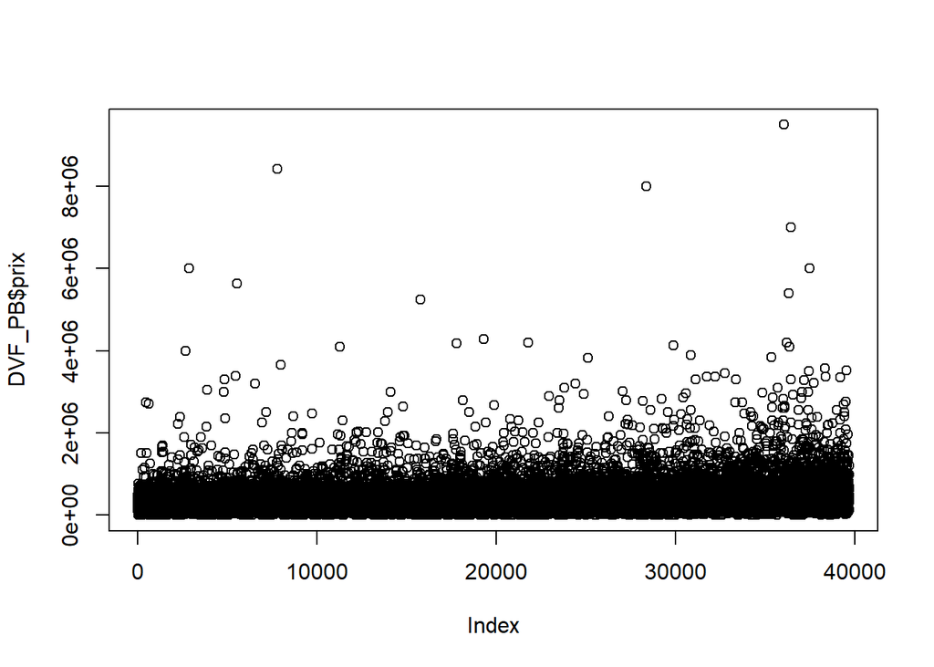

```r
plot(DVF_PB$prix)
```

```r
summary(DVF_PB$prix)
```

```
##    Min. 1st Qu.  Median    Mean 3rd Qu.    Max.
##       1  147000  217000  297070  349759 9500000
```

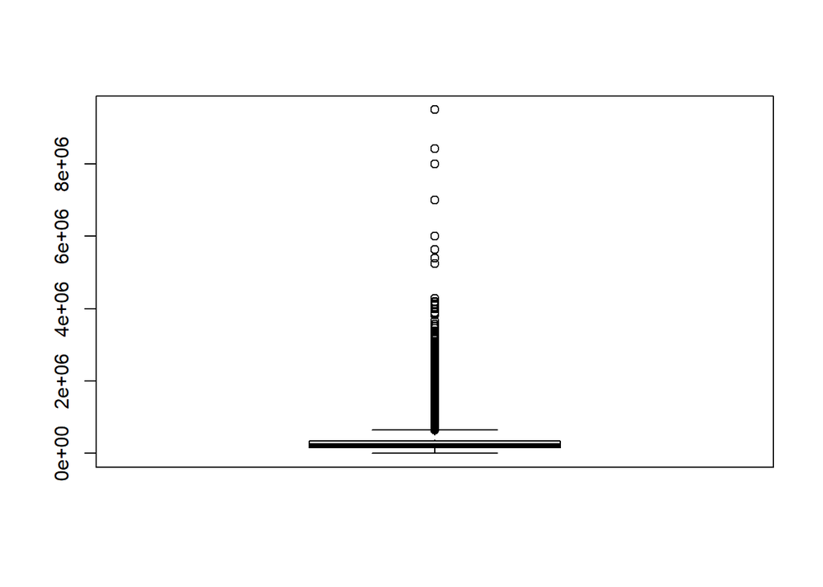

```r
boxplot(DVF_PB$prix)
```

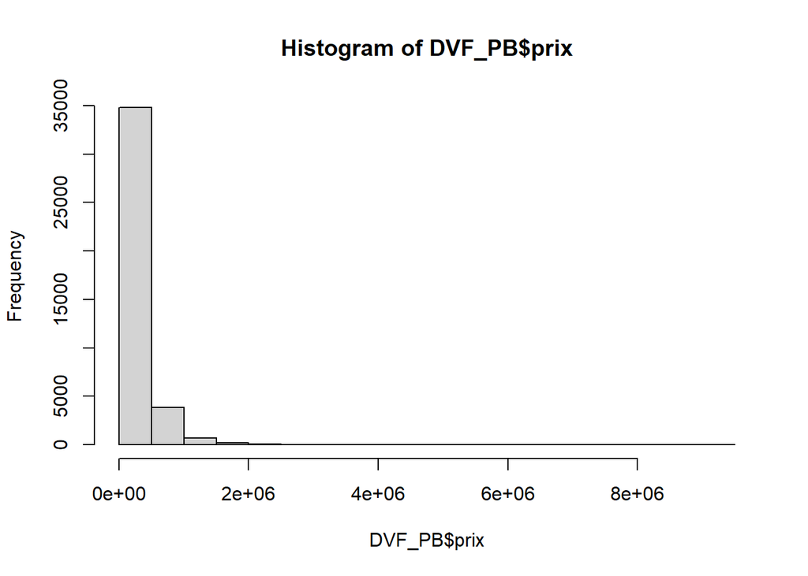

```r
hist(DVF_PB$prix)
```

# Suppression des valeurs aberrantes

## Fixer un seuil minimal et maximale des prix (percentiles)

Ici, nous allons déterminer les seuils pour exclure les valeurs trop extrêmes. On détermine alors le seuil minimal avec quantile(DVF_PB$prix, 0.01) et le seuil maximal avec quantile(DVF_PB$prix, 0.99).

```r
quantile(DVF_PB$prix, 0.01)
```

```
##    1%
## 30000
```

```r
quantile(DVF_PB$prix, 0.99)
```

```
##     99%
## 1457750
```

#### Fixer un seuil maximal des prix (histogramme)

```r
options(scipen=999)
summary(FranceEntiereOK$prix)
```

```
##       Min.    1st Qu.     Median       Mean    3rd Qu.       Max.
##          0     108000     175000    1593340     294000 3300000000
```

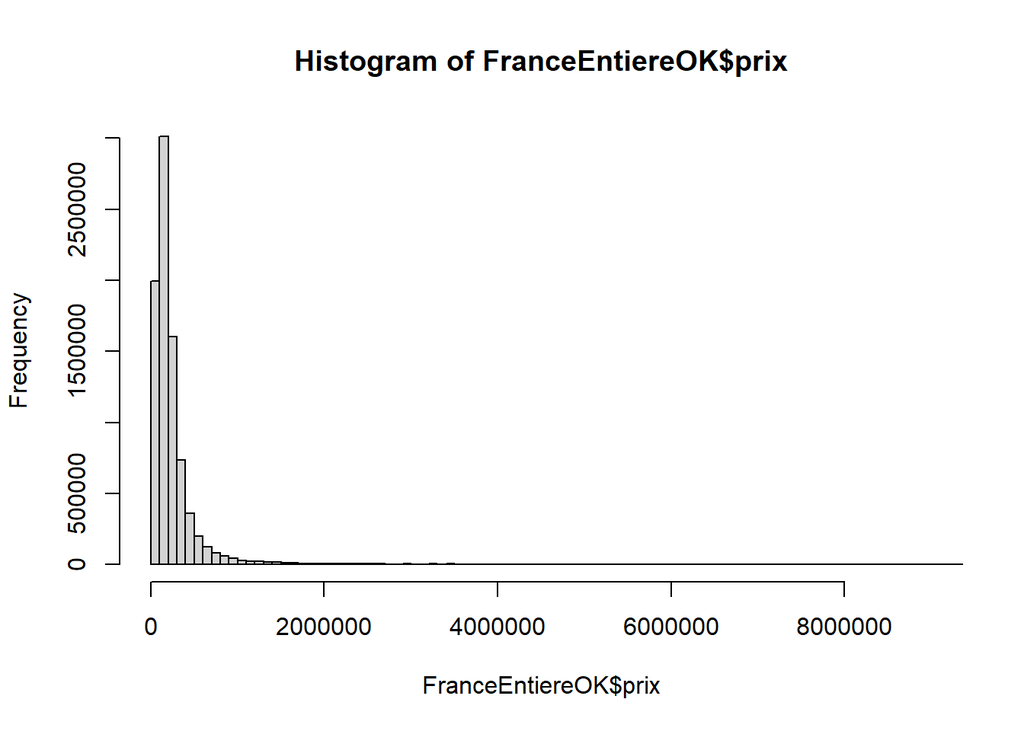

```r
hist(FranceEntiereOK$prix, breaks = 30000, xlim = c(0,9000000))
```

#### Créer deux jeux de données (maisons / appartements)

```r
Maisons <- DVF_PB %>% filter(type == 'Maison')
Appartements <- DVF_PB %>% filter (type == 'Appartement')
```

#### Fixer un seuil maximal des surfaces (histogramme)

Avec les réprésentations des données sous forme d”histogramme nous avons pu déterminer visuellement les différents seuil à adopter pour la suite de l’analyse.

```r
summary(Maisons$surface)
```

```
##    Min. 1st Qu.  Median    Mean 3rd Qu.    Max.
##    1.00   87.25  110.00  122.90  146.00  633.00
```

```r
summary(Appartements$surface)
```

```
##    Min. 1st Qu.  Median    Mean 3rd Qu.    Max.
##    1.00   40.00   57.00   59.42   73.00  608.00
```

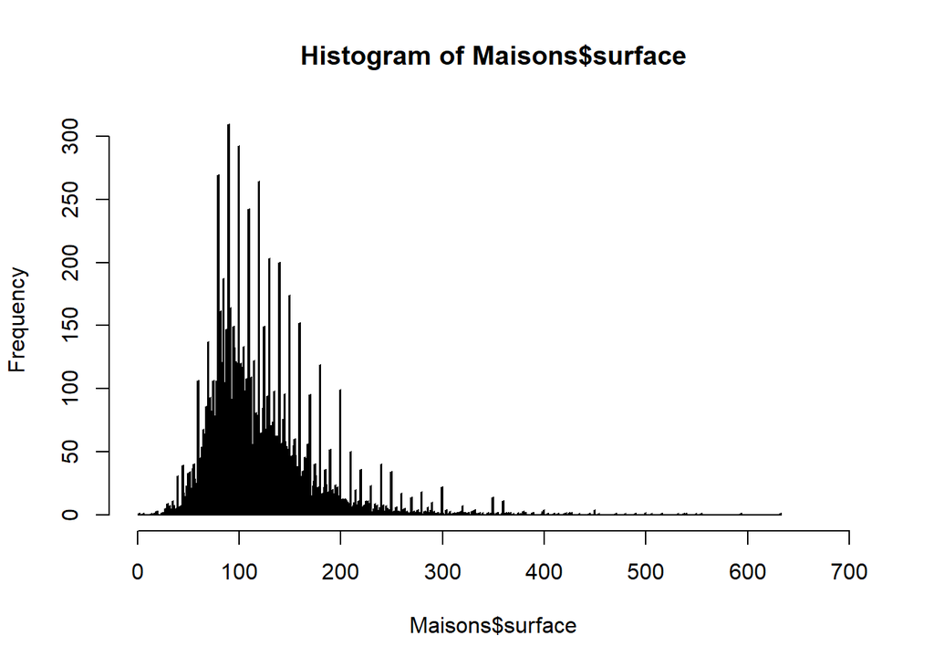

```r
hist(Maisons$surface, nclass = 500, xlim = c(0,700))
```

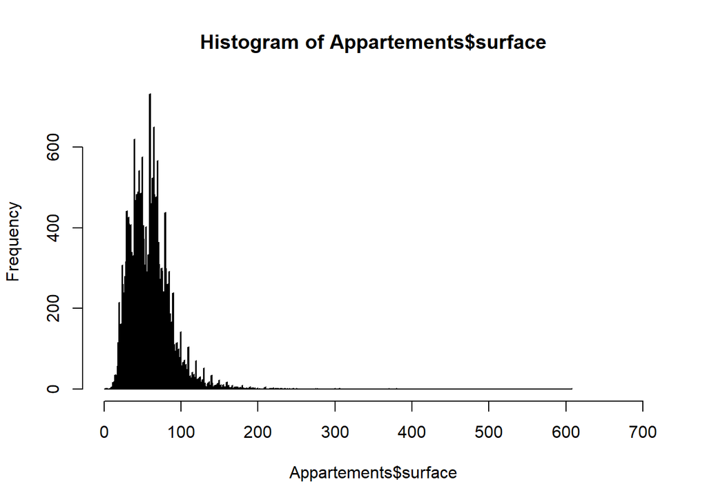

```r
hist(Appartements$surface, nclass = 500, xlim = c(0,700))
```

## Sélection des bornes de prix et de surface

De la même manière que pour les surfaces, nous reproduisons le même système avec les prix.

```r
summary(Maisons$prix)
```

```
##    Min. 1st Qu.  Median    Mean 3rd Qu.    Max.
##       1  235000  357024  454542  540950 8421205
```

```r
summary(Appartements$prix)
```

```
##    Min. 1st Qu.  Median    Mean 3rd Qu.    Max.
##       1  135000  185000  228286  265000 9500000
```

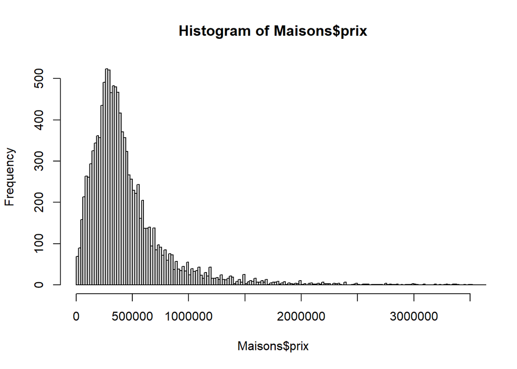

```r
hist(Maisons$prix, nclass = 500, xlim = c(0,3500000))
```

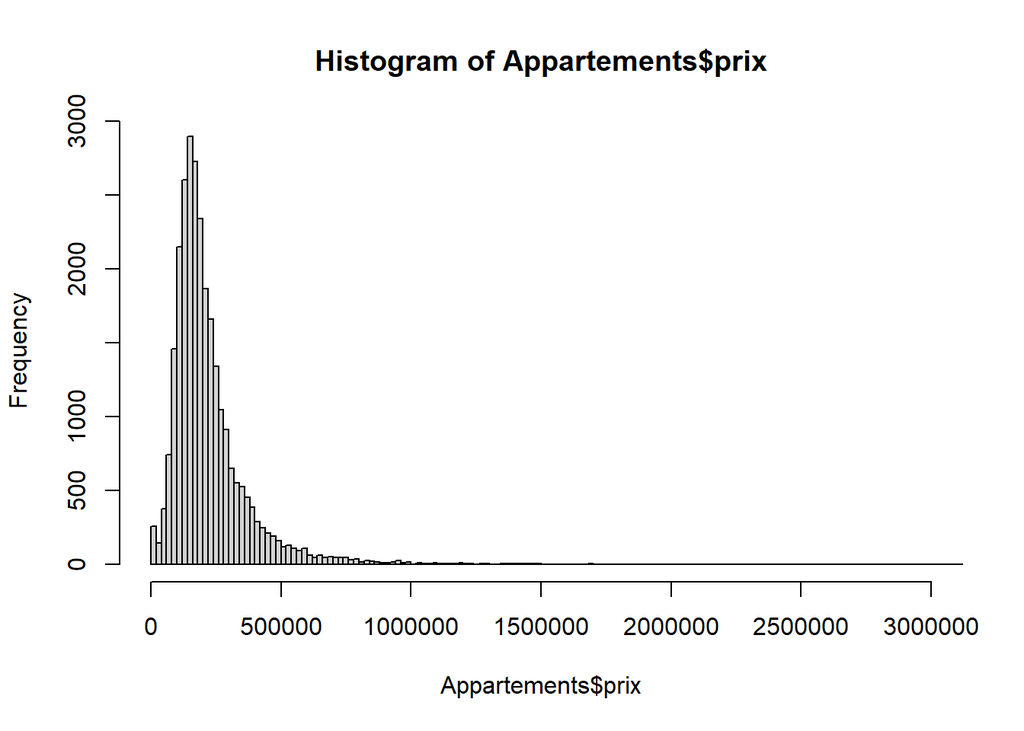

```r
hist(Appartements$prix, nclass = 500 , xlim = c(0,3000000))
```

```r
Bornes <- DVF_PB %>% filter(between(prix, 15000, 3500000)) %>%
          filter(case_when(type == 'Appartement' ~ between(surface, 9, 300)) |
           case_when(type == 'Maison' ~ between(surface, 9, 500)))
```

## Calcul du prix au m² et exclusion des valeurs extrêmes et aberrantes

```r
Prixm2 <- Bornes %>% mutate(prixm2 = prix/surface)
```

#### Fixer un seuil minimal des prix au m² (percentile)

```r
quantile(Prixm2$prixm2, 0.01)
```

```
##       1%
## 590.9091
```

#### Fixer un seuil maximal des prix au m² (histogramme)

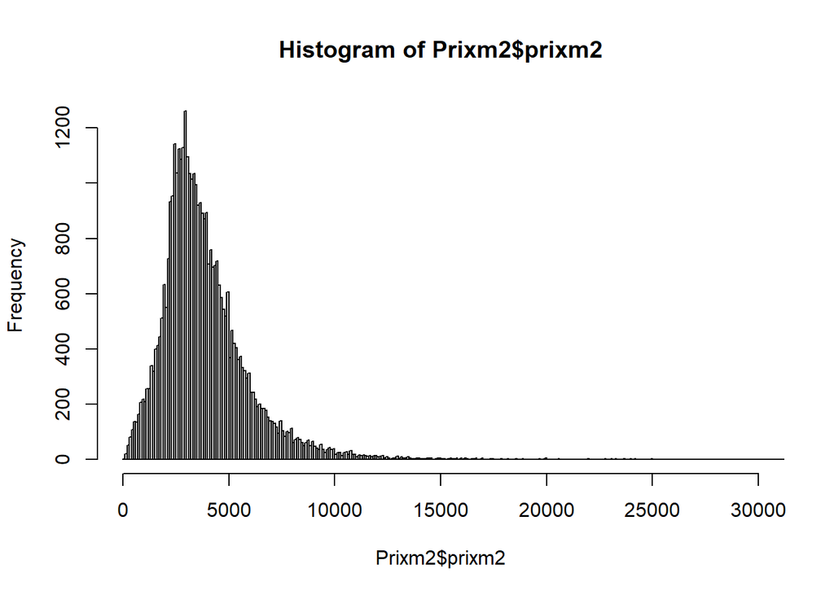

```r
hist(Prixm2$prixm2, breaks = 1000, xlim = c(0,30000))
```

#### Filtres des valeurs

```r
BornesPrixm2 <- Prixm2 %>% filter(between(prixm2,591,20000))
```

#### Extraction de l’année à partir de la date

```r
BornesPrixm2 <- BornesPrixm2 %>% mutate(annee = substr(BornesPrixm2$date, 1, 4))
```

#### Arrondir les valeurs

```r
BornesPrixm2$prix <- round(BornesPrixm2$prix)
BornesPrixm2$prixm2 <- round(BornesPrixm2$prixm2)
```

# Enrichissement des mutations avec de nouvelles variables

Ici avc la fonction merge on va fusionner les dataframes ensembles.

```r
COM_PB <- COM_PB %>% mutate(codecommune = INSEE_COM)
DVF_COM <- merge(BornesPrixm2, COM_PB, by = "codecommune")

TYPOINSEE <- read.csv("TYPOINSEE.csv", sep = ",", encoding = "UTF-8")
TYPOINSEE <- TYPOINSEE %>% mutate(codecommune = Code)
DVF_TYPO <- merge(DVF_COM, TYPOINSEE, by = "codecommune")
```

### Structuration du jeu de données final

L’utilisation de select de cette manière permet de créer un nouveau dataframe contenant uniquement les colonnes nécessaires à notre analyse.

```r
DVFOK <- DVF_TYPO %>% select(id, date, annee, type, prix, surface, prixm2, codecommune, commune = NOM_M, Typo_INSEE = typo, latitude, longitude)
```

### Exporter le jeu de données final en csv

```r
write.csv(DVFOK, 'DVFOK.csv', quote = FALSE, row.names = FALSE)
```

### Diagnostic des types de mutations

#### Calcul du nombre de mutations

```r
length(unique(DVFOK$id))
```

```
## [1] 38928
```

#### Nombre de mutations multiventes

```r
MutationsComplexes <- nbunique %>% filter(nb > 1)
length(unique(MutationsComplexes$id))
```

```
## [1] 1964
```

#### Nombre de mutations monoventes/monolignes

Ici, nous allons regrouper tous les ID avec group_by, et summarize va créer un nouveau DataFrame avec les colonnes PRIX, SURFACE et nb, le nombre de lignes dans chaque groupe.

La fonction unique_simple permet de filtrer les ID pour lesquels le nombre de transactions est égal à 1.

```r
uniquesimple <- FranceEntiereOK %>% group_by(id) %>% summarise(prix = first(prix), surface = first(surface), nb = n())
nbtransactionssimplemonoligne <- uniquesimple %>% filter(nb == 1)
length(unique(nbtransactionssimplemonoligne$id))
```

```
## [1] 5774739
```

#### Nombre de mutations monoventes/multilignes

```r
A <- length(unique(FranceEntiereOK$id))
B <- length(unique(nbtransactionssimplemonoligne$id))
A - B
```

```
## [1] 1018070
```

#### Diagnostic du nombre de biens par mutation

```r
diaggroup <- nbunique %>% mutate(as.character(nb)) %>% group_by(nb) %>% summarise(tot = n())
```

#### Nombre de mutations multiventes, nombre total et nombre moyen de biens associés

```r
length(MutationsComplexes$id)
```

```
## [1] 1964
```

```r
sum(MutationsComplexes$nb)
```

```
## [1] 4981
```

```r
mean(MutationsComplexes$nb)
```

```
## [1] 2.536151
```